# Designing base animations

In this lesson, we will add simple animations to the battlers. We will make them move forward and back, but also add an animation to represent taking damage. If you lack a sprite for visualization animations, you can find one in the Godot project that comes with the course.

Here, I’m assuming you know how to use Godot’s animation editor. I am not going to explain how it works in detail work here. You can learn how the editor works using the following free resources:

- [Getting started with the AnimationPlayer editor in Godot](https://youtu.be/18Em80Bfjp4) (video)
- [Introduction to the animation features](https://docs.godotengine.org/en/stable/tutorials/animation/introduction_2d.html)

## The scene’s setup

Then are two problems to address when setting up your game for character animation:

- You want your artists to be able to work on the animation without overriding their teammates’ work.
- You want to set up the position nodes so the animation does not interfere with code that would update the character’s position.

Let’s set up the scene to get started. We need a little rig to give our animations some flexibility. Create a new scene with a *Position2D* as its root node. Name it *BattlerAnim*.

Below you can see the setup. There is a second *Position2D* node named *Pivot* that we will control using the *AnimationPlayer*. That way, even if you want to move the root node using GDScript code, you can do so.

I’ve attached a new script named `BattlerAnim.gd` to the root node.

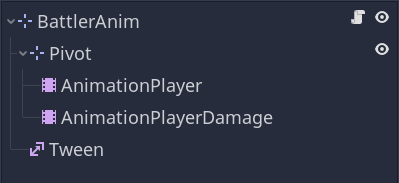

We have a second *AnimationPlayer* named *AnimationPlayerDamage* here so we can layer two animations.

During development, I had only one animation player initially, which led to a bug. The poison status effect could stack to the point the battler would keep playing the damage animation and never finish its turn.

There is also a *Tween* node that we’ll use to move the root note forward and back. We need the tween here because the battler can face two different directions, left or right, and in either case, we want to animate it moving forward.

## Designing animations

It’s time to add some simple animations. To visualize your work, you can select the *Pivot* node and drag and drop a sprite into the scene.

Select the *AnimationPlayer* node and create a *setup* animation which we’ll use to reset the *Pivot* node to its default state. With the *Pivot* selected, key its *Modulate*, *Position*, and *Visible* properties. I’ve also set the animation to *Autoplay on Load* by clicking the sign-like icon to the right of the animation drop-down menu.

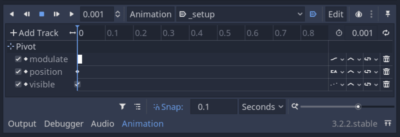

The attack animation should move the battler forward (towards the left, by convention) and back to its start position. Below, you can also see a *Functions* track that calls the method `emit_signal()` and emits the `triggered` signal.

We’ll use the signal to consume a hit on our `AttackAction` objects. This setup allows you to design attacks and spells that hit multiple times and with precise timings.

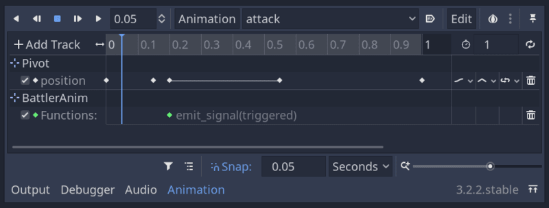

To call functions in animations as in the image above, you want to create a *Call Method Track*:

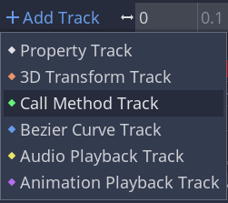

When you insert a keyframe on such a track, a window opens and lets you select a function to call. To set the function’s arguments, click on the key in the animation editor and in the *Inspector*, expand *Args*.

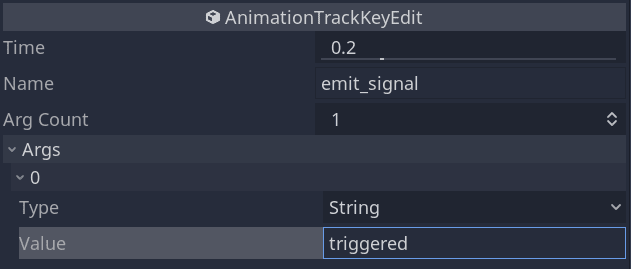

The die animation tints the node red and makes it blink by animating its *Modulate* property. To do so, you want to alternate keyframes between a red and a white tone. The last keyframe is still red, but with the alpha channel dragged to zero, which makes the sprite fade out.

The scale track maintains the node’s scale to `(1, 1)` until the `0.35` seconds mark. Then, I stretched the character by scaling it vertically, and then squash it down.

I also used the animation to toggle the node’s visibility. This is a safeguard: I mostly do that to avoid bad surprises at run-time.

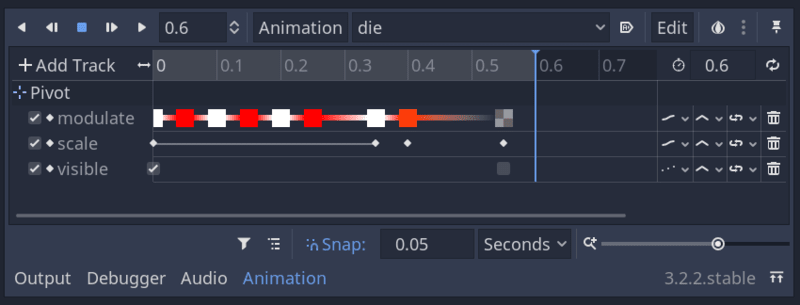

Next, let’s select the *AnimationPlayerDamage* node and add a *take_damage* animation to it.

This animation is similar to *die*, except it only animates the node’s *Modulate* property, and at the end of the animation, we remove any tint from the node.

Notice the keys’ timings below: the character initially blinks fast and the effect slows down after a few split seconds.

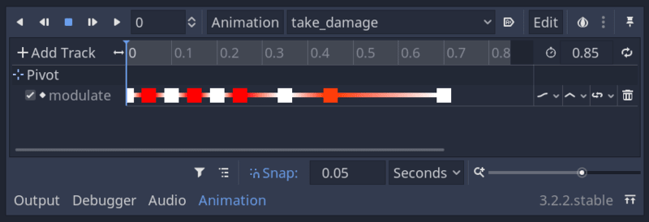

## Creating derived battler scenes

Until now, we had temporary *Battler* instances as a child of our *ActiveTurnQueue*, in the *CombatDemo* scene. We’re going to create two derived scenes for the playable character and the enemy.

While we could code `Battler.gd` to customize every battler instance a lot in the *Inspector*, as your game grows, the list of required properties to do so will grow too and become hard to manage.

You will likely need some battlers to be unique in some ways, and to do so you’ll need specialized scenes that favor composition over inheritance. It’s the most flexible way to work in Godot, at little cost.

You could use the scene inheritance feature in Godot. I recommend to avoid it: if you change the parent scene’s structure, you can lose data in inherited scenes without warning. There are other known issues with changes from the parent scene not propagating to inherited ones.

That’s why, instead, I recommend creating new scenes, which is what we’ll do here.

In *CombatDemo*, remove the two *Battler* instances. We’ll replace them with two new scenes. For each scene:

1. Duplicate `Battler.tscn` in the *FileSystem* tab, name the new file after your battler, and open the new scene.
2. Instantiate `BattlerAnim.tscn` as a child of the scene’s root. We use this instance to give our battler a skin.
3. Right-click on *BattlerAnim* and turn on *Editable Children*.
4. Add a *Sprite* as a child of the *Pivot* node. To do so, I select the *Pivot* and drag and drop a PNG file from the *FileSystem* onto the viewport. You can use the textures `bear.png` and `bugcat.png`.

Your battler scenes should look like this.

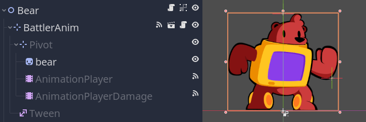

I created two scenes, `Bear.tscn` and `BugCat.tscn`. In the *CombatDemo*, instantiate each of them as a child of the *ActiveTurnQueue*.

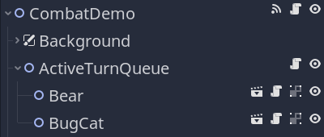

*In this demo, the battlers aren’t what they would be in a larger game project. Here, we’re using the Editable Children feature for testing purposes. Instead, in a complete game, you may want to export an extra property on the BattlerAnim class to assign it an animated skin. But while prototyping, Editable Children does the job.*

In the next lesson, we will code the `BattlerAnim` and start playing animations.